```python
import numpy as np
import matplotlib.pyplot as plt
import csv
from sklearn.cluster import KMeans
from sklearn.cluster import AgglomerativeClustering #to make scatterplot
from scipy.cluster import hierarchy # to make dendogram
```

# Setup

```python
X = []
with open('HW3train.csv', 'r') as csvfile:
    reader = csv.reader(csvfile, delimiter=',',lineterminator='\n')
    for row in reader:
        if len(row)==3:
            X.append( [float(row[1]) , float(row[2]) ])

X = np.array(X)
```

```python
#define colors to be used for plotting cluters (using hex values)
# you can pick more/different using https://htmlcolorcodes.com/
#  or https://www.w3schools.com/colors/colors_picker.asp
colors = np.array(['#377eb8', '#ff7f00', '#4daf4a', \
                         '#f781bf', '#a65628', '#984ea3', \
                         '#999999', '#e41a1c', '#dede00',\
                         '#707b7c', '#58d68d', '#1a5276',\
                         '#641e16', '#f5cba7', '#212f3d'])
```

# 3A Scatter plot

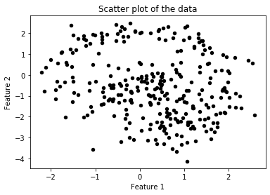

```python
plt.figure()
plt.scatter(X[:, 0], X[:, 1], s=20,color='k')

plt.title('Scatter plot of the data')
plt.xlabel('Feature 1')
plt.ylabel('Feature 2')

plt.show()
```

# 3B K means

#### Scatter plot

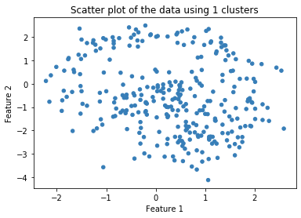

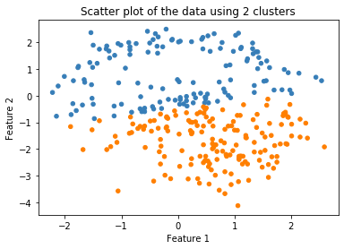

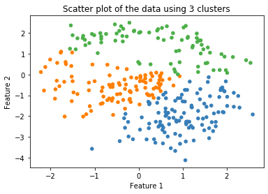

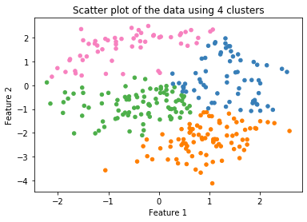

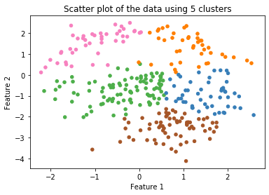

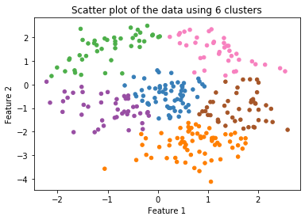

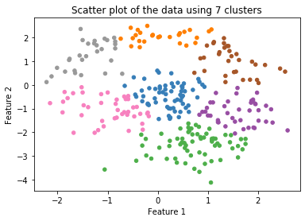

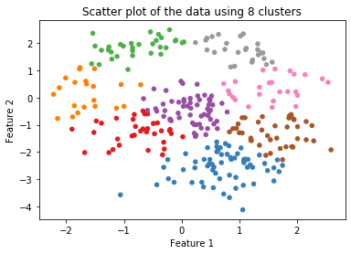

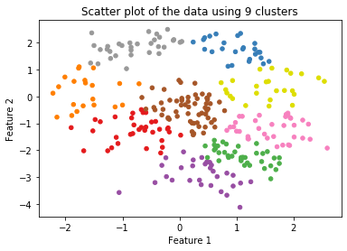

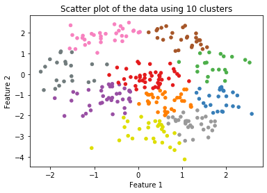

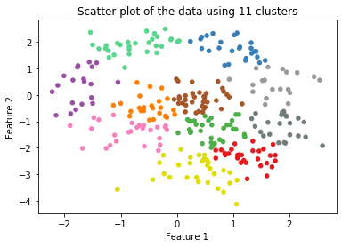

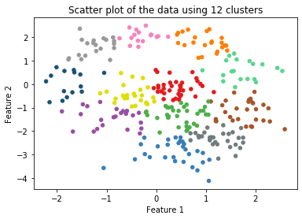

[3 more figures not shown]

```python
for i in range(1,16):
    clustering = KMeans(n_clusters=i, n_init=50, max_iter=250, n_jobs=-1, init='random')
    clustering.fit(X)

    # Plot the training points
    plt.figure()
    plt.scatter(X[:, 0], X[:, 1], s=20,color=colors[clustering.labels_])
    plt.title('Scatter plot of the data using %i clusters'%(i))
    plt.xlabel('Feature 1')
    plt.ylabel('Feature 2')

    plt.show()
```

# Hierarchical (aka 'Agglomerative') Clustering

First we will make a dendogram, then pick a distance threshold to make a scatter plot

### 3C Single linkage (cluster distance = min pairwise distance)

#### Dendogram

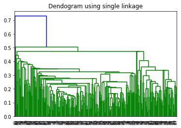

```python
link = 'single'

Xlink = hierarchy.linkage(X, link)
plt.figure()
plt.title('Dendogram using %s linkage'%(link))
dn = hierarchy.dendrogram(Xlink)
```

### 3D Scatter plot

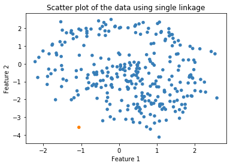

```python
thresh=0.6

clustering = AgglomerativeClustering(n_clusters=None, \
                     affinity='euclidean',linkage=link, \
                     distance_threshold=thresh,compute_full_tree=True)

clustering.fit(X)

# Plot the training points
plt.figure()
plt.scatter(X[:, 0], X[:, 1], s=20,color=colors[clustering.labels_])
plt.title('Scatter plot of the data using %s linkage'%(link))
plt.xlabel('Feature 1')
plt.ylabel('Feature 2')

plt.show()
```

#### Dendogram

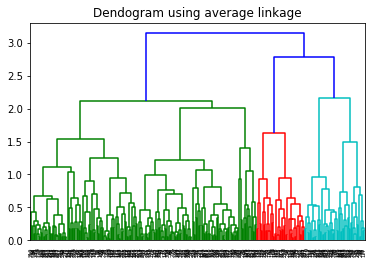

```python
link = 'average'
Xlink = hierarchy.linkage(X, link)
plt.figure()
plt.title('Dendogram using %s linkage'%(link))
dn = hierarchy.dendrogram(Xlink)
```

```python
#### Scatter plot
```

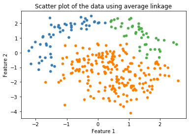

```python
thresh=2.5

clustering = AgglomerativeClustering(n_clusters=None, \
                     affinity='euclidean',linkage=link, \
                     distance_threshold=thresh,compute_full_tree=True)

clustering.fit(X)

# Plot the training points
plt.figure()
plt.scatter(X[:, 0], X[:, 1], s=20,color=colors[clustering.labels_])
plt.title('Scatter plot of the data using %s linkage'%(link))
plt.xlabel('Feature 1')
plt.ylabel('Feature 2')

plt.show()
```

### 3F Complete linkage (cluster distance = max pairwise distance)

#### Dendogram

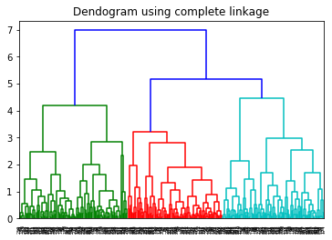

```python
link = 'complete'
Xlink = hierarchy.linkage(X, link)
plt.figure()
plt.title('Dendogram using %s linkage'%(link))
dn = hierarchy.dendrogram(Xlink)
```

#### Scatter plot

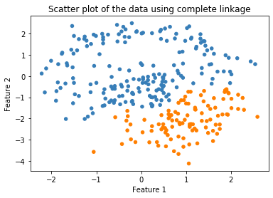

```python
thresh=6

clustering = AgglomerativeClustering(n_clusters=None, \
                     affinity='euclidean',linkage=link, \
                     distance_threshold=thresh,compute_full_tree=True)

clustering.fit(X)

# Plot the training points
plt.figure()
plt.scatter(X[:, 0], X[:, 1], s=20,color=colors[clustering.labels_])
plt.title('Scatter plot of the data using %s linkage'%(link))
plt.xlabel('Feature 1')
plt.ylabel('Feature 2')

plt.show()
```

#### 3G

For K-means, I think 3, 4, 5 and 6 are among the better clustering results (visually speaking). K=2 partitions too low (eg I think the central blue points should be orange). But all seem to split up the points into somewhat compact regions (eg the top arch is all green in K=3 but then split by K>= 4). This is partly due to K-means using centroid distance alone which works well for circlular regions but not other shapes.

Single linkage -- from the dendogram, there seems to be a clear gap between the final merger and the previous one, but it turns out to result in a cluster of a single sample and another cluster of everything else. This visually does not seem meaningful. (such behavior is not atypical for single linkage - clusters tend to form by single samples merging with bigger clusters, rather than distinct medium sized clusters merging together)

Average linkage -- this is much better than single (at least on this data set). The clusters are more compact, which can be seen by the more-balanced dendogram and the resulting scatter plot. With the chosen threshold, it breaks up that top arch (which I think should be one group) and merges everything below it, which seems fine.

Complete linkage -- the scatter plot is for threshold of 6, though you can also look at threshold around 3.5. Though for the chosen value of 6, there are two clusters. The orange region does seem distinct from the top blue arch and the denser blue region in the center, though it seems the latter two blue regions should probably have been split.

I don't think any method greatly out-performed the others, as K-means, average-linkage, and complete-linkage all gave clusters that seemed to either split regions that should be together or keep together regions that visually should not be. The clustering with the selected threshold for single linkage was unambiguously bad, though. Overall, though, I would probably go with average linkage.

One important take-away is that each of the methods can been seen as suggesting underlying features in the data, and even if they are not perfect, they can give good suggestions for us to consider, especially in higher dimensions where we cannot easily look at the data all together (unless we do multiple 2d plots with different pairs of features).